# A&A Project : Covid-19 Precondition Anslysis.

Hongshen_Lee

11/22/2020

# Are you in danger of being affected by Corona Virus?

## 1.Acknowleagement

### 1.1 Background

Coronavirus disease (covid-19) is a newly discovered infectious disease caused by a coronavirus. It is a kind of virus that is aimed at the respiratory tract of susceptible patients. According to WHO, this is the fourteenth worldwide pandemic. Due to the characteristics of today’s world, the epidemic is the most widespread and is suffering almost all over the world.

Most people infected with covid-19 experience mild to moderate respiratory disease that can be cured without special treatment. Older people, as well as those with underlying diseases such as cardiovascular disease, diabetes, chronic respiratory disease, and cancer, are more likely to develop serious diseases.

Obviously, the virus has different degrees of impact on different physical conditions. I hope to be able to find out the relationship between the preconditions and the severity of symptoms after infection. This study will help us to make more informed decisions on what aspects we can consciously protect ourselves, how to protect specific vulnerable groups, and what degree of measures should be taken for people infected with the virus.

### 1.2 Dataset Description

This data-set was released by the Mexican government. This data-set contains 566,602 records of anonymised patient-related information.

**Data Dictionary:**

1. `id`: The identification number of the patient
2. `sex`: Identify gender of the patient, 1 as female and 2 as male.
3. `patient_type`: Type of patient, 1 for not hospitalized and 2 for hosptalized.
4. `entry_date`: The date that the patient went to the hospital.
5. `date_symptoms`: The date that the patient started to show symptoms.
6. `date_died`: The date that the patient died, “9999-99-99” stands for recovered.
7. `intubed`: Intubation is a procedure that’s used when you can’t breathe on your own. Your doctor puts a tube down your throat and into your windpipe to make it easier to get air into and out of your lungs. A machine called a ventilator pumps in air with extra oxygen. Then it helps you breathe out air that’s full of carbon dioxide (CO2). “1” denotes that the patient used ventilator and “2” denotes that the patient did not, “97” “98” “99” means not specified.
8. `pneumonia`: Indicates whether the patient already have air sacs inflammation or not “1” for yes, “2” for no, “97” “98” “99” means not specified.
9. `age`: Specifies the age of the patient.
10. `pregnancy`: Indicates whether the patient is pregnant or not, “1” for yes, “2” for no, “97” “98” “99” means not specified.
11. ``diabetes`: Indicates whether the patient has diabetes or not, “1” for yes, “2” for no, “97” “98” “99” means not specified.
12. `copd`: Indicates whether the patient has Chronic obstructive pulmonary disease (COPD) or not, “1” for yes, “2” for no, “97” “98” “99” means not specified.
13. `asthma`: Indiactes whether the patient has asthma or not, “1” for yes, “2” for no, “97” “98” “99” means not specified.
14. `inmsupr`: Indicates whether the patient is immunosuppressed or not, “1” for yes, “2” for no, “97” “98” “99” means not specified.
15. `hypertension`: Indicates whether the patient has hypertension or not, “1” for yes, “2” for no, “97” “98” “99” means not specified.
16. `other_disease`: Indicates whether the patient has other disease or not, “1” for yes, “2” for no, “97” “98” “99” means not specified.
17. `cardiovascular`: Indicates whether if the patient has heart or blood vessels realted disease, “1” for yes, “2” for no, “97” “98” “99” means not specified.
18. `obesity`: Indicates whether the patient is obese or not, “1” for yes, “2” for no, “97” “98” “99” means not specified.
19. `renal_chronic`: Indicates whether the patient has chronic renal disease or not, “1” for yes, “2” for no, “97” “98” “99” means not specified.
20. `tobacco`: Indicates whether if the patient is a tobacco user, “1” for yes, “2” for no, “97” “98” “99” means not specified.
21. `contact_other_covid: Indicates whether if the patient has contacted another covid19 patient.
22. `icu`: Indicates whether the if the patient had been admitted to an Intensive Care Unit (ICU), “1” for yes, “2” for no, “97” “98” “99” means not specified.
23. `covid_res`: 1 indicates person is covid +ve,2 indicates person is covide -ve,3 indicates result is in awaiting process

### 1.3 Work Blueprint

1. Summarize the data to give descriptive statistics
2. Clean and normalize the data
3. Build the Linear Regression Model to determine the factor affecting the results.

**Notes:**

The analysis is valid for Mexico or maybe North America. The pandemic stats and behaviors are extremely different for Asian countries when compared to North American or European countries owing to a far lower case fatality rate for Asia.

## 2.Data Processing

### 2.1 Load And Clean Data

1. As mentioned above, `97`,`98`and `99` have no specific meanings
2. For most fields, `1` represents yes, `2` represents no

```r
input.data.file <- "./data/covid.csv"

d <- read_csv(input.data.file)

d[d==97] <- NA
d[d==98] <- NA
d[d==99] <- NA


head(d)
```

```
## # A tibble: 6 x 23
##   id      sex patient_type entry_date date_symptoms date_died intubed pneumonia
##   <chr> <dbl>        <dbl> <chr>      <chr>         <chr>       <dbl>     <dbl>
## 1 1616~     2            1 04-05-2020 02-05-2020    9999-99-~      NA         2
## 2 1009~     2            1 19-03-2020 17-03-2020    9999-99-~      NA         2
## 3 1673~     1            2 06-04-2020 01-04-2020    9999-99-~       2         2
## 4 0b59~     2            2 17-04-2020 10-04-2020    9999-99-~       2         1
## 5 0d01~     1            2 13-04-2020 13-04-2020    22-04-20~       2         2
## 6 1bee~     2            2 16-04-2020 16-04-2020    29-04-20~       2         1
## # ... with 15 more variables: age <dbl>, pregnancy <dbl>, diabetes <dbl>,
## #   copd <dbl>, asthma <dbl>, inmsupr <dbl>, hypertension <dbl>,
## #   other_disease <dbl>, cardiovascular <dbl>, obesity <dbl>,
## #   renal_chronic <dbl>, tobacco <dbl>, contact_other_covid <dbl>,
## #   covid_res <dbl>, icu <dbl>
```

### 2.2 Data Exploration

Since there are many two-value(yes or no) fields, we can consider whether it’s a valid factor by comparing their counts in different `covid_res` groups.

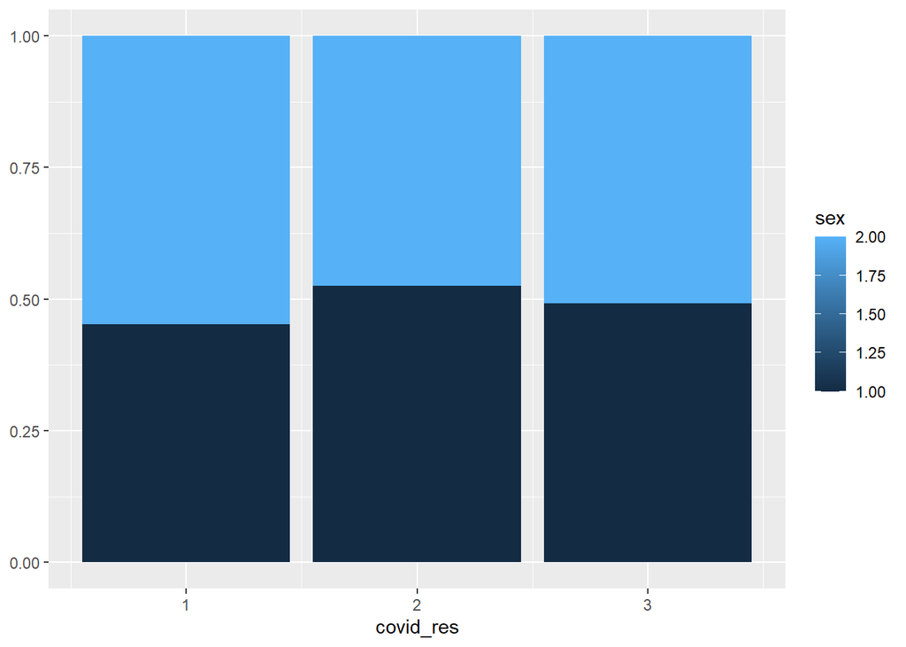

```r
field_analysis<-function(d,field)
{
  d %>%
  count(covid_res,{{field}}) %>%
  ggplot(mapping = aes(
    x = covid_res,
    y = n,
    fill ={{field}} ))+
  geom_col(position = "fill") +
  labs(y = NULL)
}

field_analysis(d,sex)
```

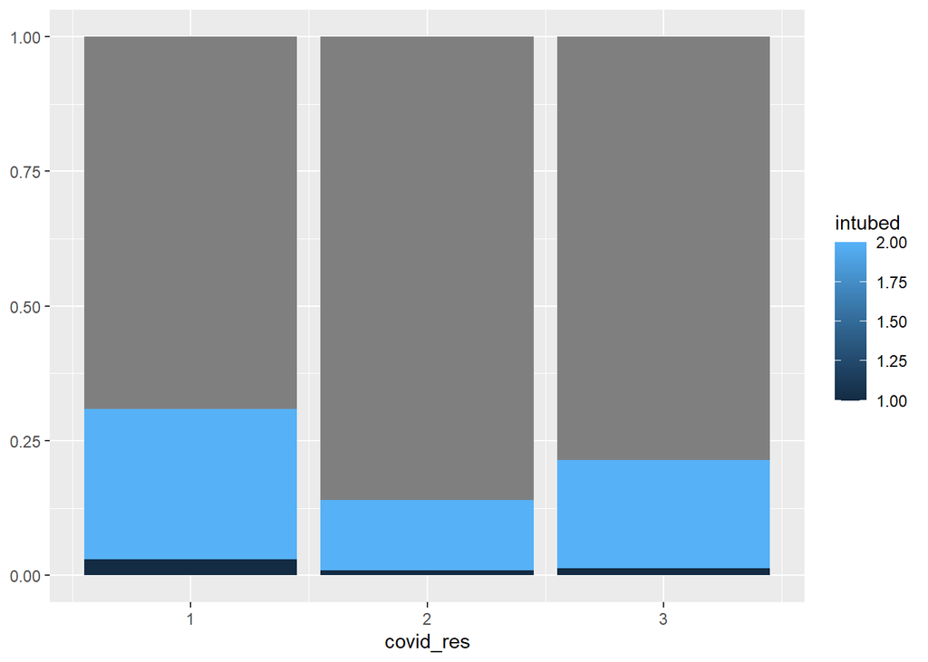

```r
field_analysis(d,intubed)
```

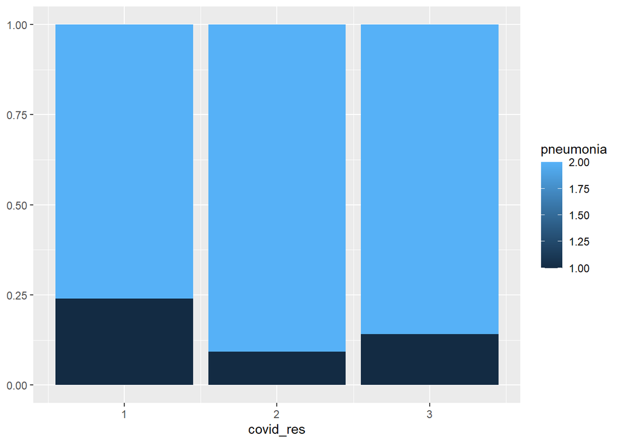

```r
field_analysis(d,pneumonia)
```

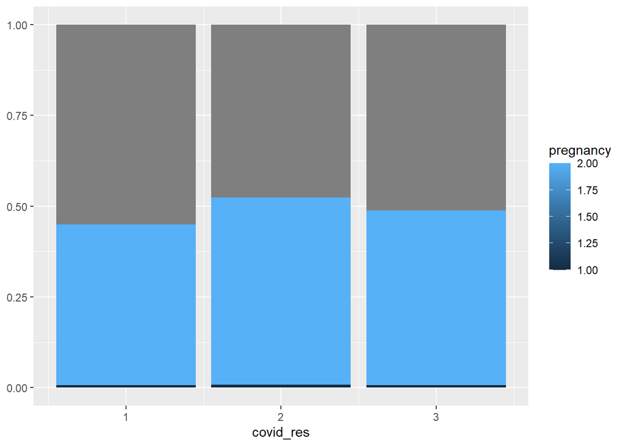

```r
field_analysis(d,pregnancy)
```

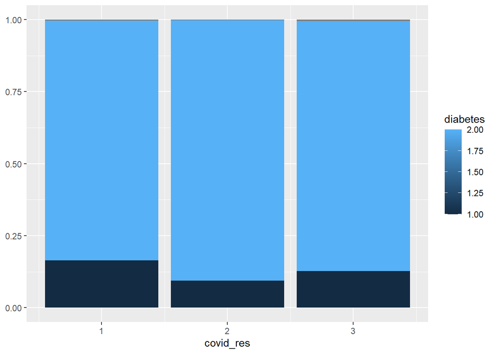

```r
field_analysis(d,diabetes)
```

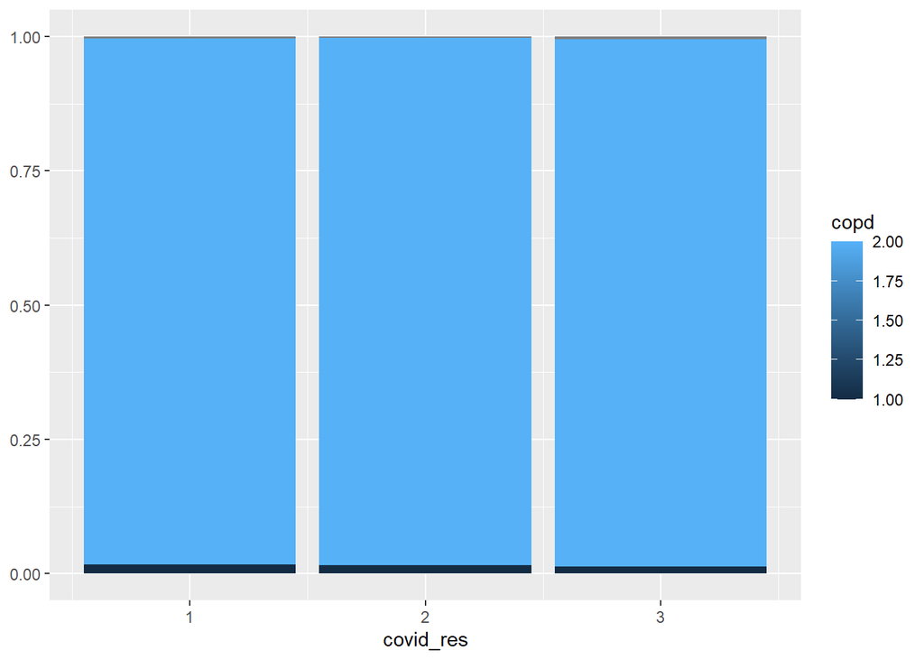

```r
field_analysis(d,copd)
```

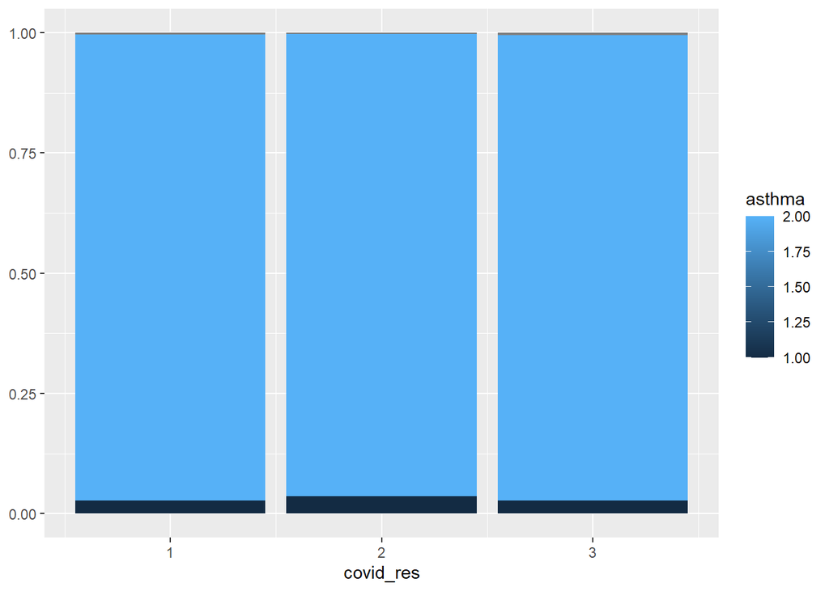

```r
field_analysis(d,asthma)
```

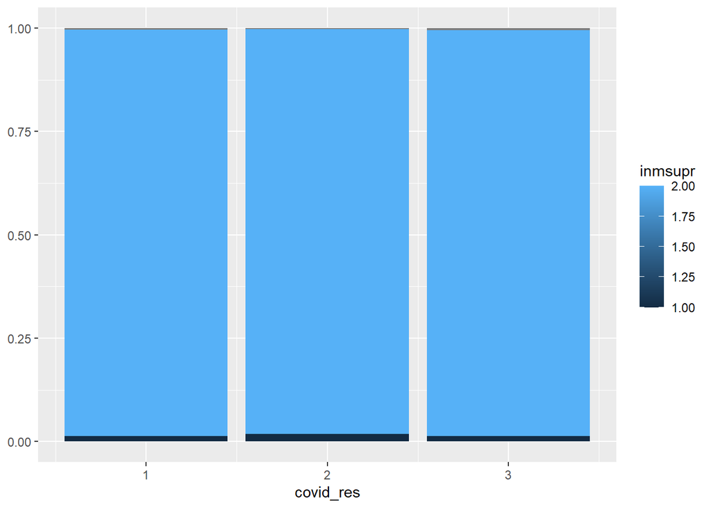

```r
field_analysis(d,inmsupr)
```

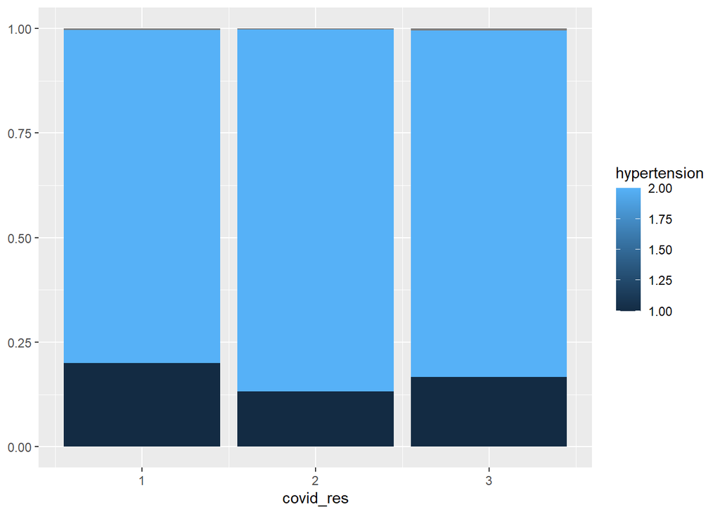

```r
field_analysis(d,hypertension)
```

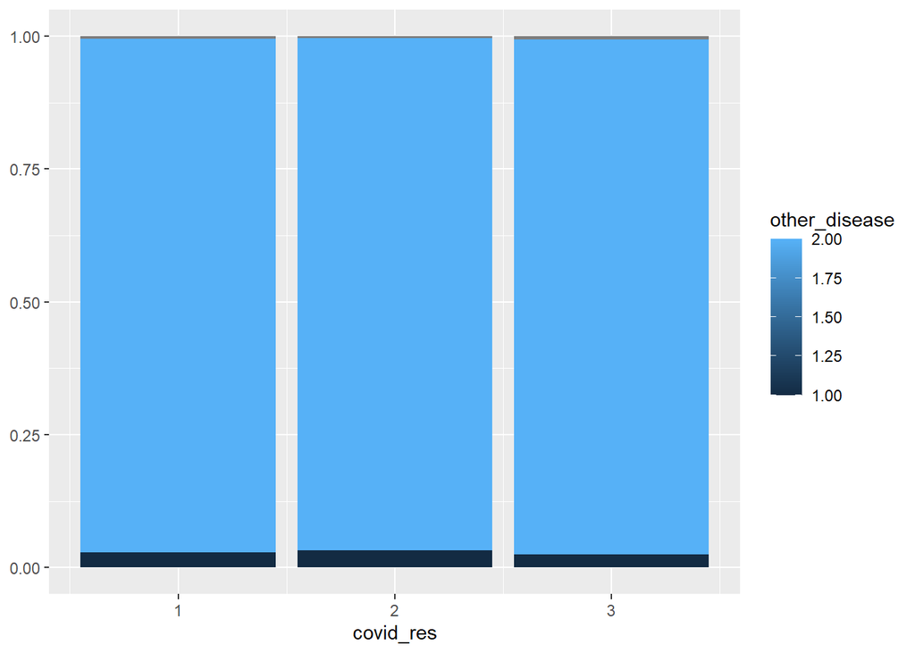

```r
field_analysis(d,other_disease)
```

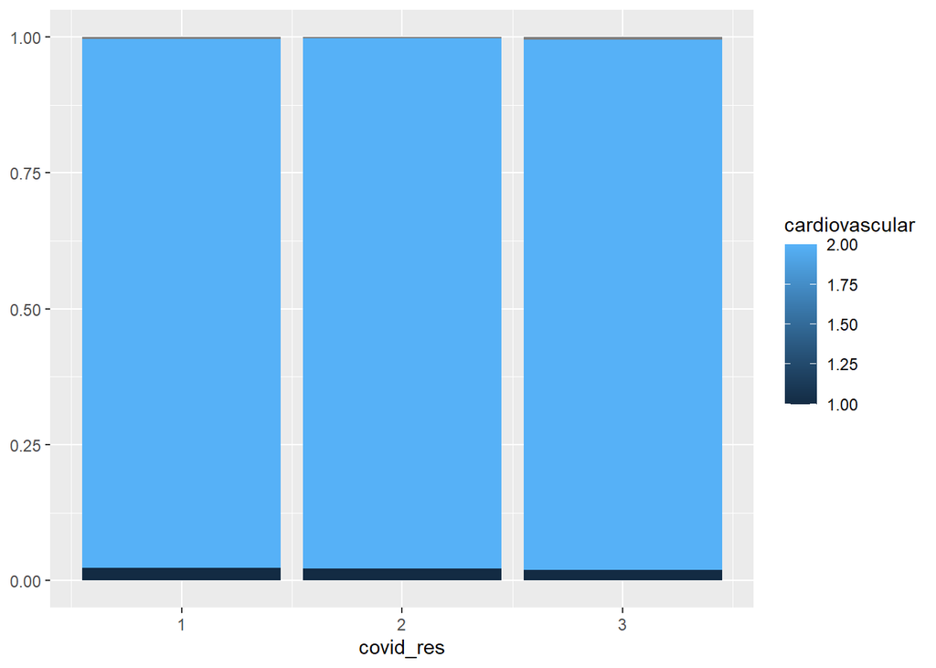

```r
field_analysis(d,cardiovascular)
```

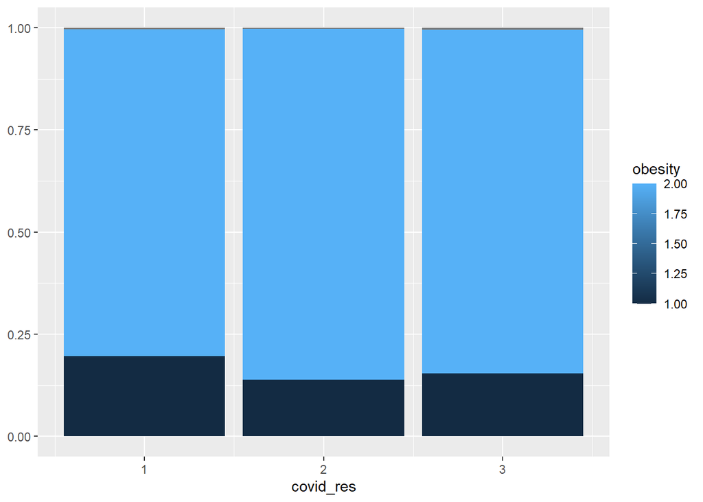

```r
field_analysis(d,obesity)
```

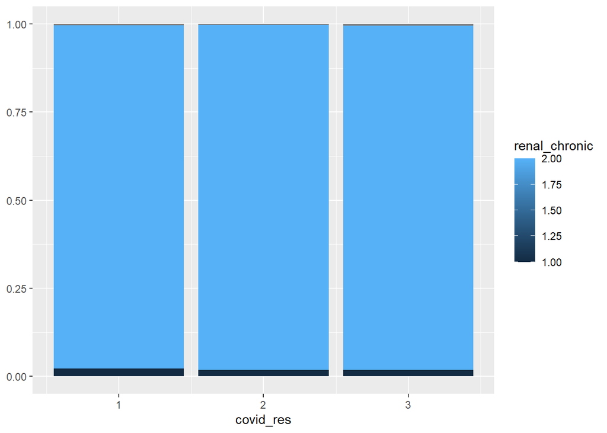

```r
field_analysis(d,renal_chronic)
```

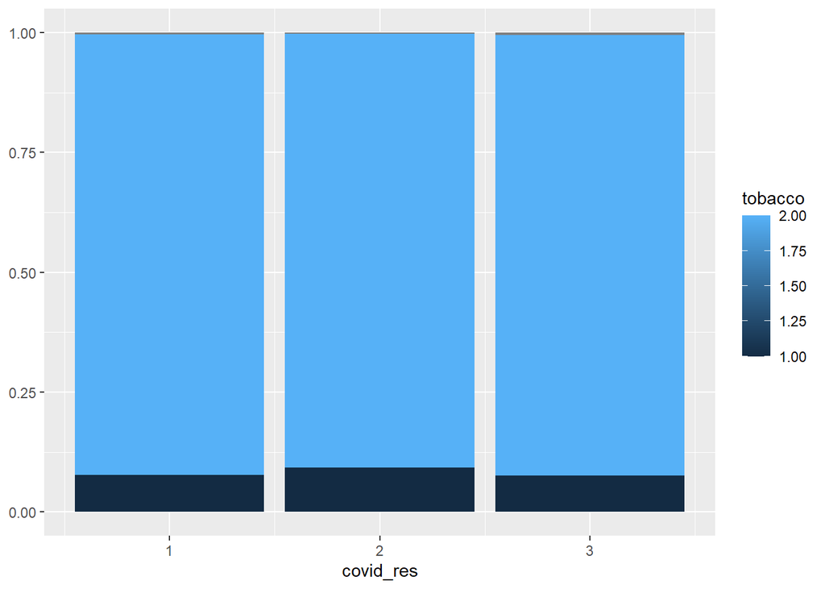

```r
field_analysis(d,tobacco)
```

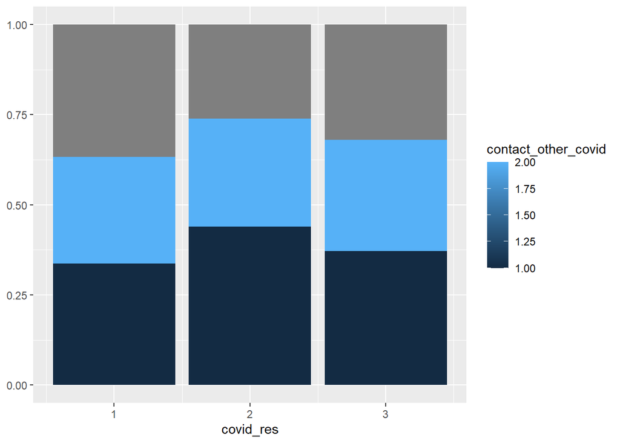

```r
field_analysis(d,contact_other_covid)
```

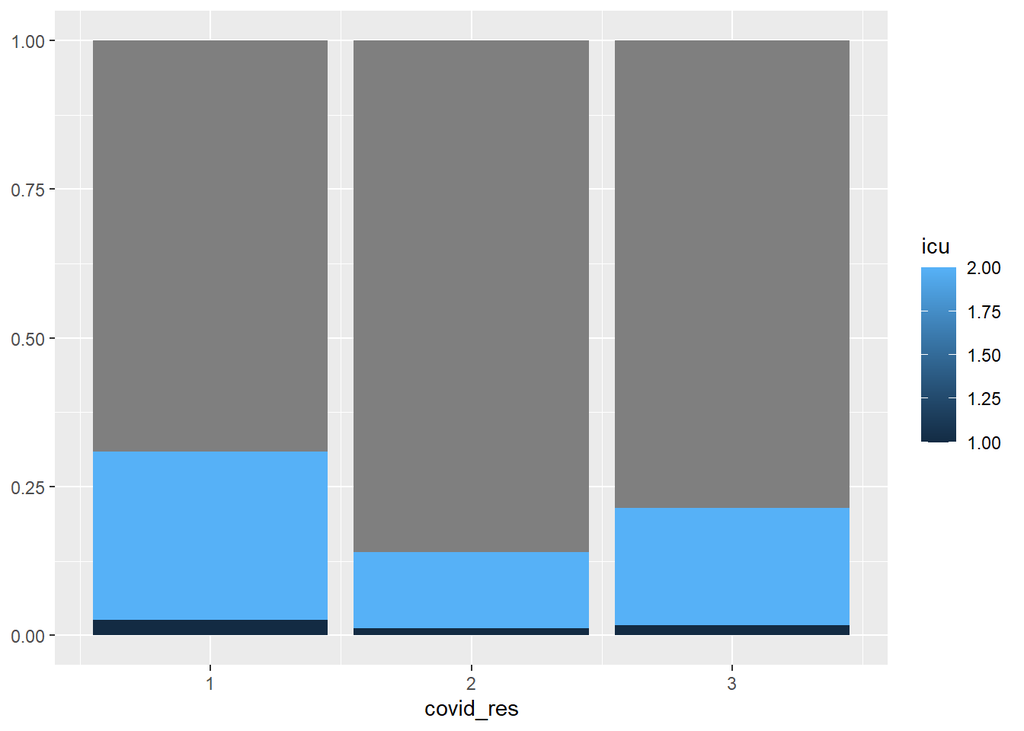

```r
field_analysis(d,icu)
```

From the graphs above, we can know fields like `copd`,`asthma`, `inmsupr`,`other_disease`, `cardiovascular`,`renal_chronic` have similar distributions among different three `covid_res` groups.

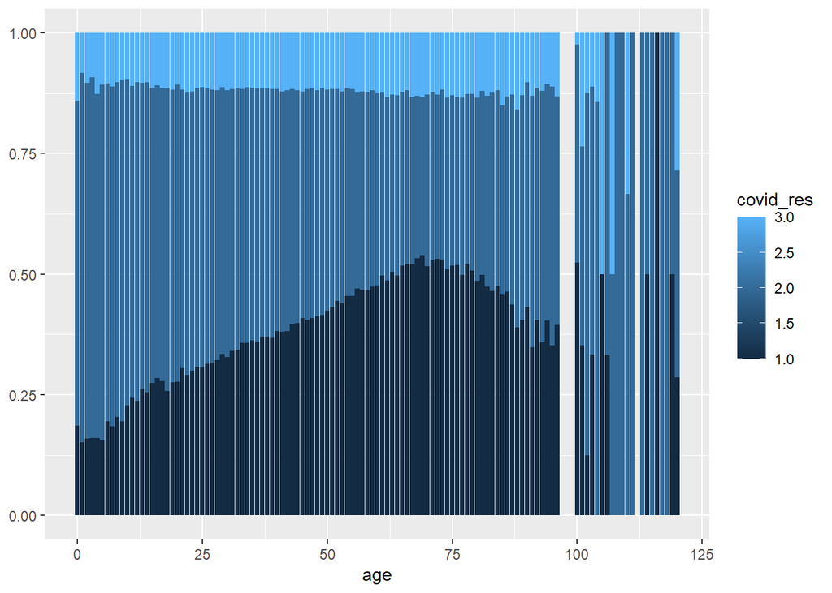

```r
d %>%
  count(covid_res,age) %>%
  ggplot(mapping = aes(
    x = age,
    y = n,
    fill =covid_res))+
  geom_col(position = "fill") +
  labs(y = NULL)
```

Thirdly, From the above plot, we see that around 75 aged people are maximum followed by around 50 and then, 25. The age is obviously related to the result

## 3 Model

From the rough analysis above, we can take some fields as the important candidates to build our models. They are `contact_other_covid`,`obesity`,`hypertension`,`pneumonia`,`diabetes`,`pregnancy`,`sex`,`icu`,`intubed`,`tobacco` and `age`.

```
##
## Call:
## lm(formula = covid_res ~ contact_other_covid + obesity + hypertension +
##     pneumonia + diabetes + pregnancy + sex + icu + intubed +
##     tobacco + age, data = d)
##
## Residuals:
##     Min      1Q  Median      3Q     Max
## -0.9796 -0.5495 -0.3498  0.4308  1.7413
##
## Coefficients: (1 not defined because of singularities)
##                       Estimate Std. Error t value Pr(>|t|)
## (Intercept)          1.0506618  0.0878528  11.959  < 2e-16 ***
## contact_other_covid  0.0533822  0.0097478   5.476 4.39e-08 ***
## obesity              0.1243379  0.0107487  11.568  < 2e-16 ***
## hypertension        -0.0254154  0.0109586  -2.319  0.02039 *
## pneumonia            0.2248165  0.0098332  22.863  < 2e-16 ***
## diabetes             0.0253964  0.0107734   2.357  0.01842 *
## pregnancy            0.0625203  0.0294955   2.120  0.03405 *
## sex                         NA         NA      NA       NA
## icu                 -0.0409534  0.0153379  -2.670  0.00759 **
## intubed              0.0724048  0.0158596   4.565 5.01e-06 ***
## tobacco             -0.0525186  0.0217045  -2.420  0.01554 *
## age                 -0.0027388  0.0002463 -11.121  < 2e-16 ***
## ---
## Signif. codes:  0 '***' 0.001 '**' 0.01 '*' 0.05 '.' 0.1 ' ' 1
##
## Residual standard error: 0.677 on 23257 degrees of freedom
##   (543334 observations deleted due to missingness)
## Multiple R-squared:  0.04767,    Adjusted R-squared:  0.04726
## F-statistic: 116.4 on 10 and 23257 DF,  p-value: < 2.2e-16
```

```
## Analysis of Variance Table
##
## Response: covid_res
##                        Df  Sum Sq Mean Sq  F value    Pr(>F)
## contact_other_covid     1     2.0    2.05   4.4677   0.03455 *
## obesity                 1   116.0  116.04 253.1639 < 2.2e-16 ***
## hypertension            1    18.6   18.63  40.6341 1.870e-10 ***
## pneumonia               1   318.6  318.64 695.1608 < 2.2e-16 ***
## diabetes                1     8.3    8.35  18.2083 1.988e-05 ***
## pregnancy               1     0.2    0.17   0.3719   0.54198
## icu                     1     0.8    0.82   1.7878   0.18120
## intubed                 1     9.9    9.90  21.6033 3.371e-06 ***
## tobacco                 1     2.3    2.31   5.0447   0.02471 *
## age                     1    56.7   56.69 123.6873 < 2.2e-16 ***
## Residuals           23257 10660.4    0.46
## ---
## Signif. codes:  0 '***' 0.001 '**' 0.01 '*' 0.05 '.' 0.1 ' ' 1
```

## 4 Conclusion

Different fields have different `Estimate` and `F-vallue`, which means they would have different degree impacts on the `covid_res` results.